# Nature Coast Aquatic Preserve

**Sampling locations by Program:**

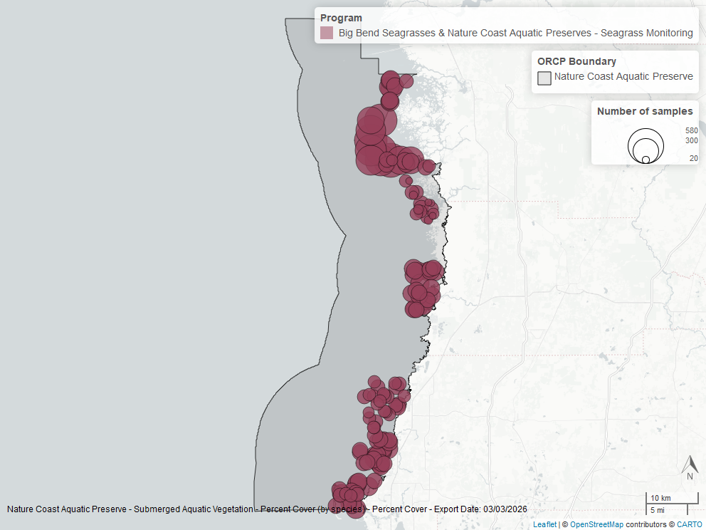

Map showing SAV sampling sites within the boundaries of *Nature Coast Aquatic Preserve*. The point size reflects the number of samples at a given sampling site.

Program Information for Submerged Aquatic Vegetation

| ProgramID | N-Data | YearMin | YearMax | method | Sample Locations |
| --- | --- | --- | --- | --- | --- |
| 560 | 11516 | 1997 | 2025 | Modified Braun Blanquet | 135 |
| 560 | 8817 | 2021 | 2025 | Percent Cover | 135 |

**Program names:**

*560* - Big Bend Seagrasses & Nature Coast Aquatic Preserves - Seagrass Monitoring<sup>12</sup>

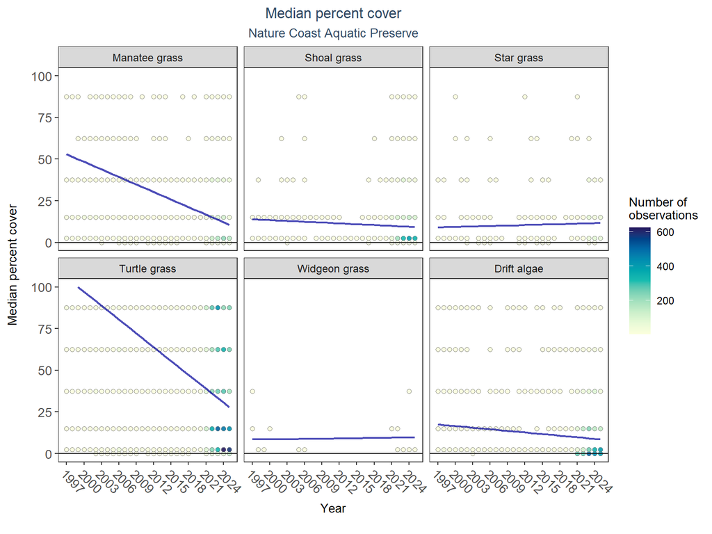

Scatter plots of median percent cover of submerged aquatic vegetation over time by group. Plots for time series that included five or more years of observations show the estimated trend as a blue line.

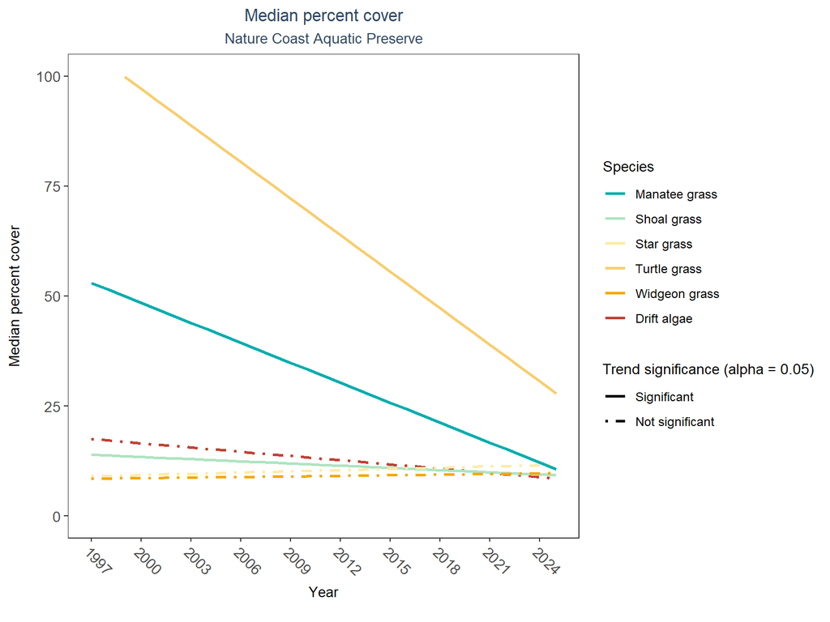

Trend lines of median percent cover of submerged aquatic vegetation over time for species that had five or more years of observations. Line type represents significance (solid) or non-significance (dashed) of the trends.

Percent Cover Trend Analysis for Nature Coast Aquatic Preserve

| Species | Statistical Trend | Period of Record | LME Intercept | LME Slope | P |
| --- | --- | --- | --- | --- | --- |
| Drift algae | No detectable trend | 1997 - 2025 | 18.460797 | -0.3194197 | 0.4315030 |
| Shoal grass | Decreasing trend | 1997 - 2025 | 14.444298 | -0.1660553 | 0.0382642 |
| Star grass | No detectable trend | 1997 - 2025 | 8.787931 | 0.0927756 | 0.3894698 |
| Widgeon grass | No detectable trend | 1997 - 2025 | 8.391523 | 0.0442851 | 0.9690043 |
| Manatee grass | Decreasing trend | 1997 - 2025 | 57.516219 | -1.5115381 | 0.0048924 |
| Turtle grass | Decreasing trend | 1997 - 2025 | 113.703116 | -2.7690575 | 0.0000000 |

Annual decreases in percent cover were observed for manatee grass (-1.51%), shoal grass (-0.17%), and turtle grass (-2.77%). Star grass, widgeon grass, and drift algae showed no detectable change in percent cover.

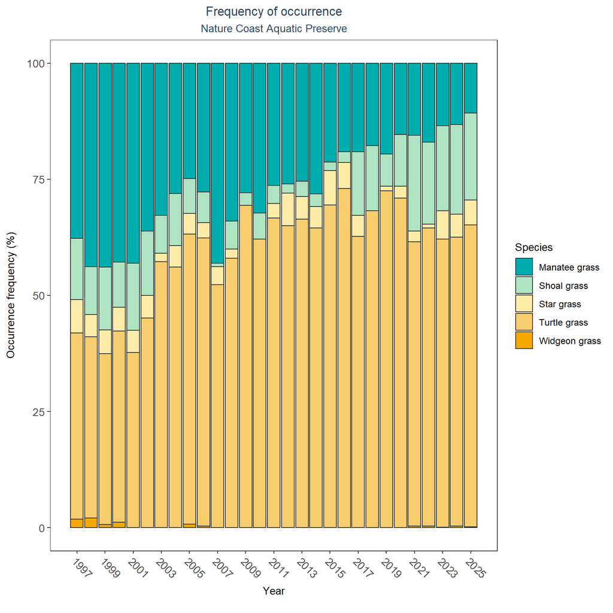

Bar plot of submerged aquatic vegetation species occurrence frequency over time by group.

## SAV Water Column Analysis

The following parameters are available for Nature Coast Aquatic Preserve within the SAV_WC_Report:

- Colored Disolved Organic Matter
- Chlorophyll a
- Dissolved Oxygen
- Dissolved Oxygen Saturation
- pH
- Salinity
- Secchi Depth
- Water Temperature
- Total Nitrogen
- Turbidity

Access the reports here: DRAFT_SAV_WC_Report.pdf

# Coastal Wetlands

The data file used is: **All_CW_Parameters-2026-Jun-04.txt**

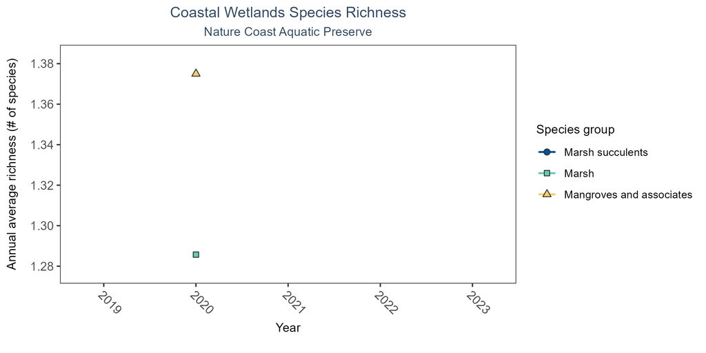

Line graph of annual average coastal wetlands species richness over time for mangroves and associates (triangles), marsh (squares), and marsh succulents (circles). If the time series by species group included more than one year of observations, a line connects data points for visualization.

Coastal Wetlands Species Richness

| Species Group | No. of Samples | No. Years with Data | Period of Record | Median No. of Taxa | Mean No. of Taxa |
| --- | --- | --- | --- | --- | --- |
| Mangroves and associates | 8 | 1 | 2020 - 2020 | 1 | 1.38 |
| Marsh | 14 | 1 | 2020 - 2020 | 1 | 1.29 |

In the year 2020, 1 species were observed for *mangroves and associates* based on 8 observations. In the year 2020, 1 species were observed for *marsh* based on 14 observations.

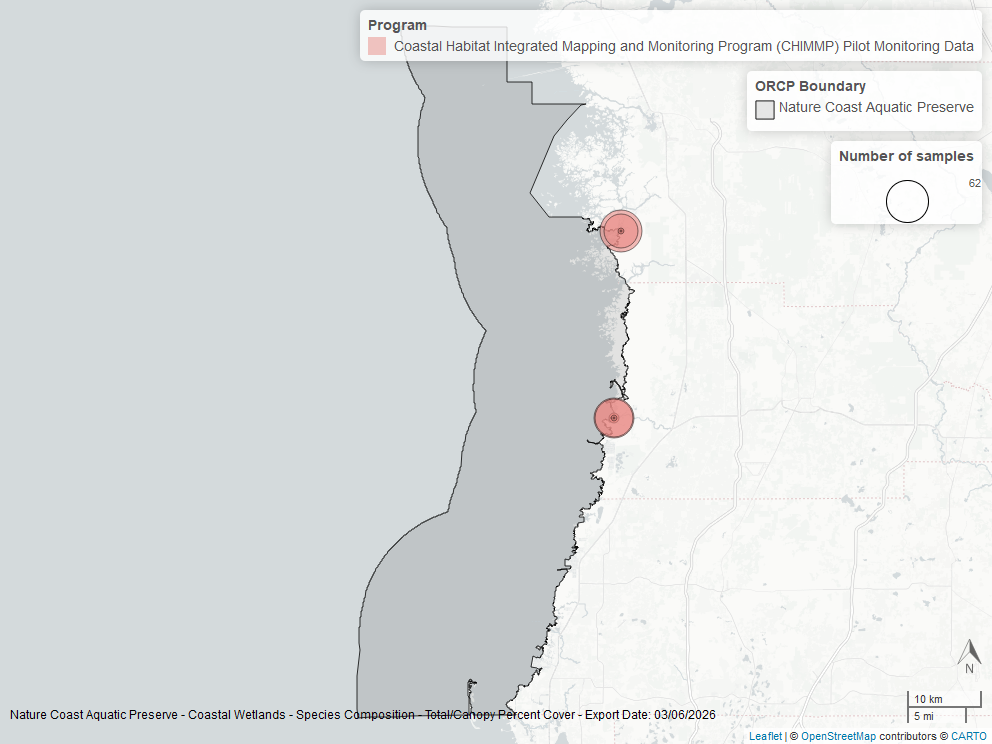

Map showing location of coastal wetlands sampling locations within the boundaries of *Nature Coast Aquatic Preserve*. The bubble size on the maps above reflect the amount of data available at each sampling site.

# Oyster

The data file used is: **All_OYSTER_Parameters-2026-Jun-04.txt**

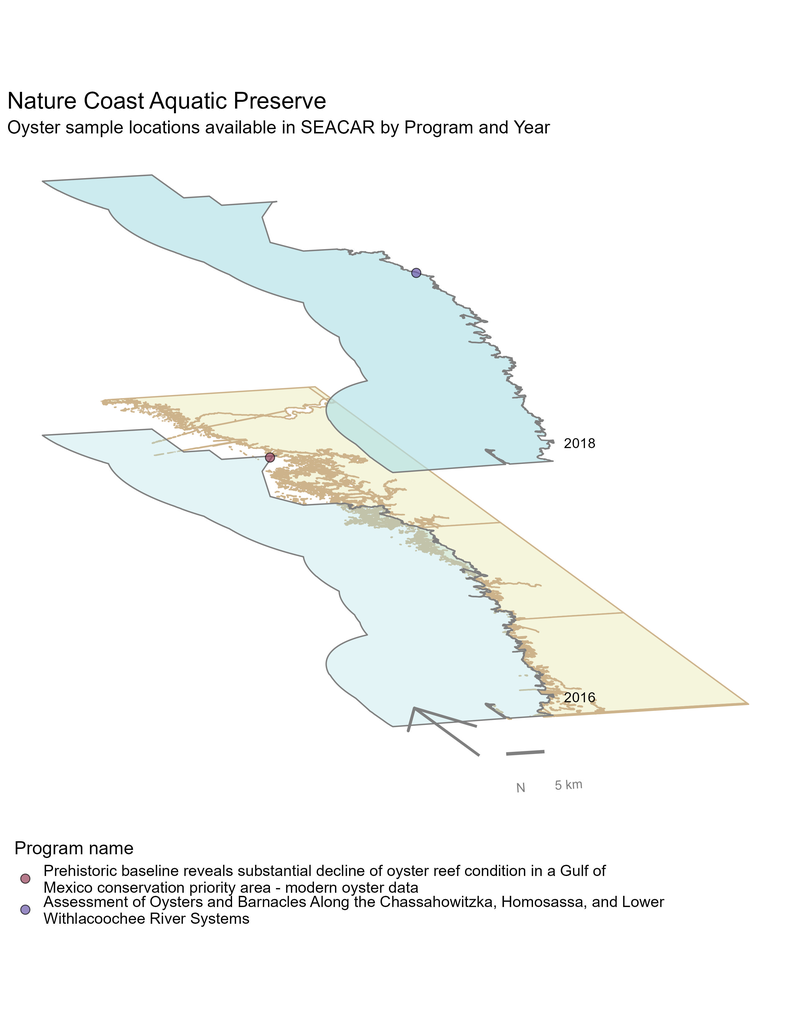

Maps showing the temporal scope of oyster sampling sites within the boundaries of *Nature Coast Aquatic Preserve* by program name.

Click [here](https://github.com/FloridaSEACAR/SEACAR_Trend_Analyses/tree/main/Oyster/output/Oyster_temporal_scope_plots) to view spatio-temporal plots on GitHub.

## Density

For natural reefs, there was insufficient data to calculate a trend for density.

### Natural

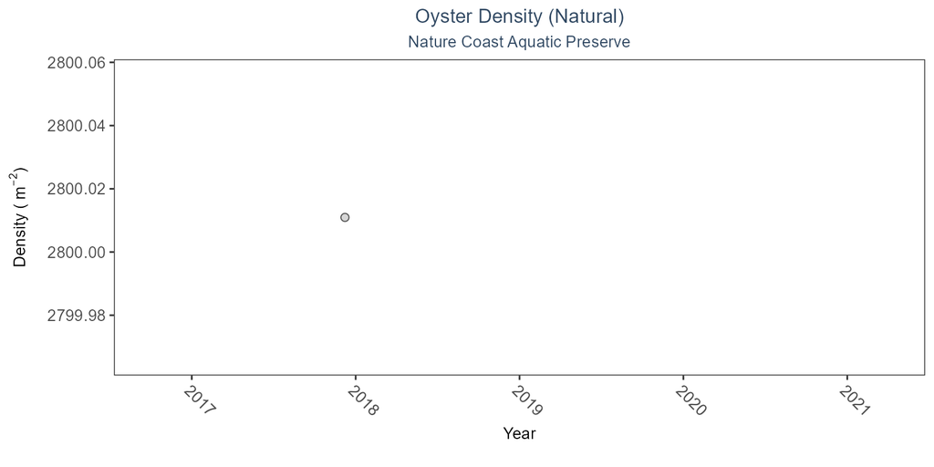

Scatter plot of oyster density over time. If the time series included five or more years with observations, an estimated trend (blue line) and a 95% credible interval (purple band) may also be plotted. Data points are jittered horizontally to reduce overlap.

Model results for Oyster Density - Natural

| Habitat Type | Shell Type | Statistical Trend | Period of Record | Estimate | Standard Error | Credible Interval |
| --- | --- | --- | --- | --- | --- | --- |
| Natural | Live Oysters | Insufficient data | 2018 - 2018 | - | - | - |

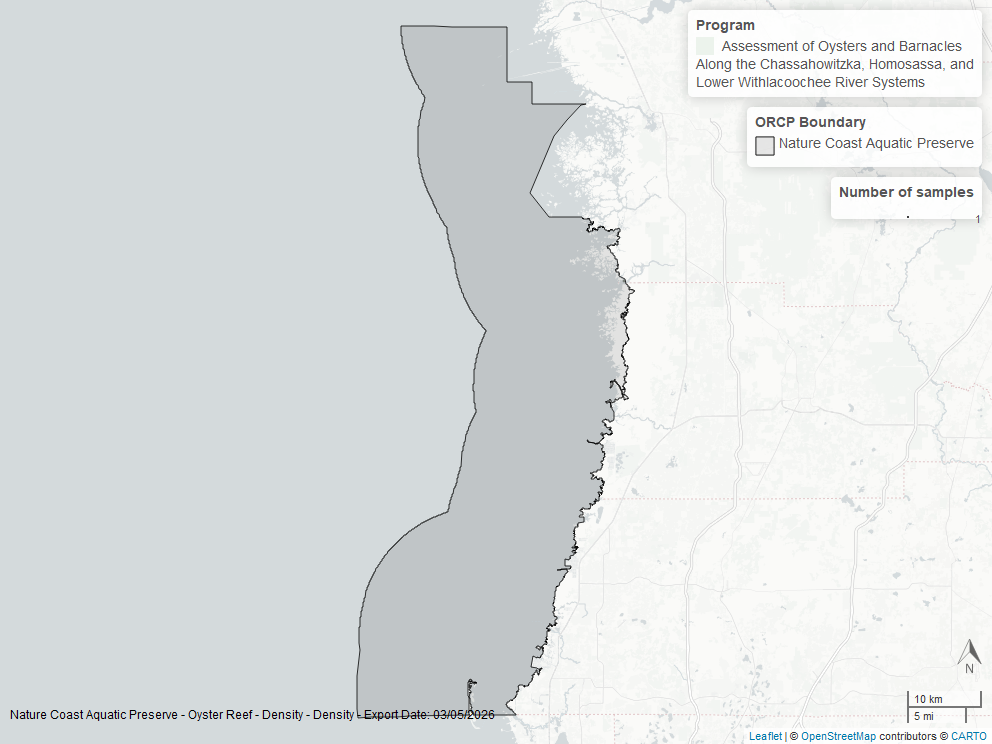

Map showing location of oyster density sampling locations within the boundaries of *Nature Coast Aquatic Preserve*. The bubble size on the maps above reflect the amount of data available at each sampling site.

## Percent Live

For natural reefs, there was insufficient data to calculate a trend for percent live cover.

### Natural

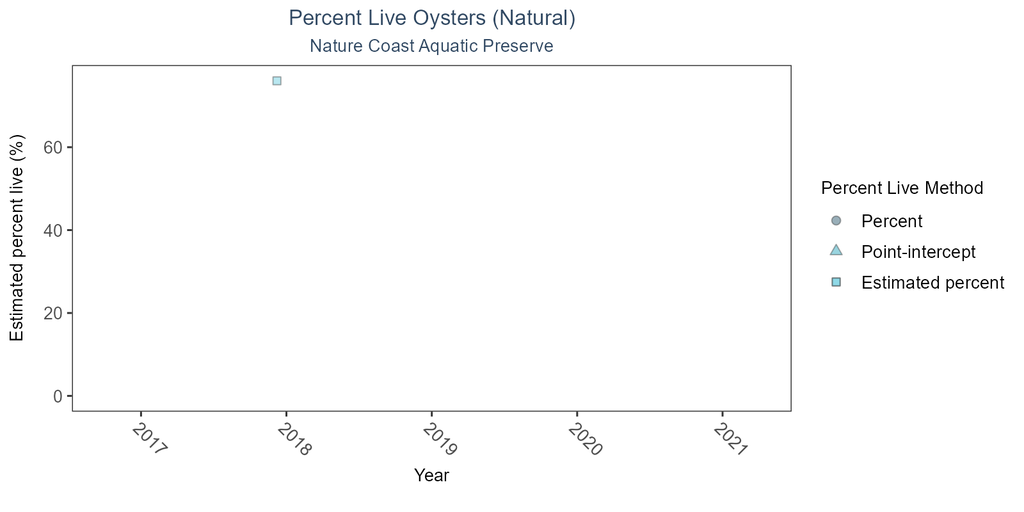

Scatter plot of percent live oysters over time. If the time series included five or more years with observations, an estimated trend (blue line) and a 95% credible interval (purple band) may also be plotted. Estimation method is represented as percent (circles), point-intercept (triangle), or estimated percent (square), with data points jittered horizontally to reduce overlap.

Model results for Oyster Percent Live - Natural

| Habitat Type | Shell Type | Statistical Trend | Period of Record | Estimate | Standard Error | Credible Interval |
| --- | --- | --- | --- | --- | --- | --- |
| Natural | Live Oysters | Insufficient data | 2018 - 2018 | - | - | - |

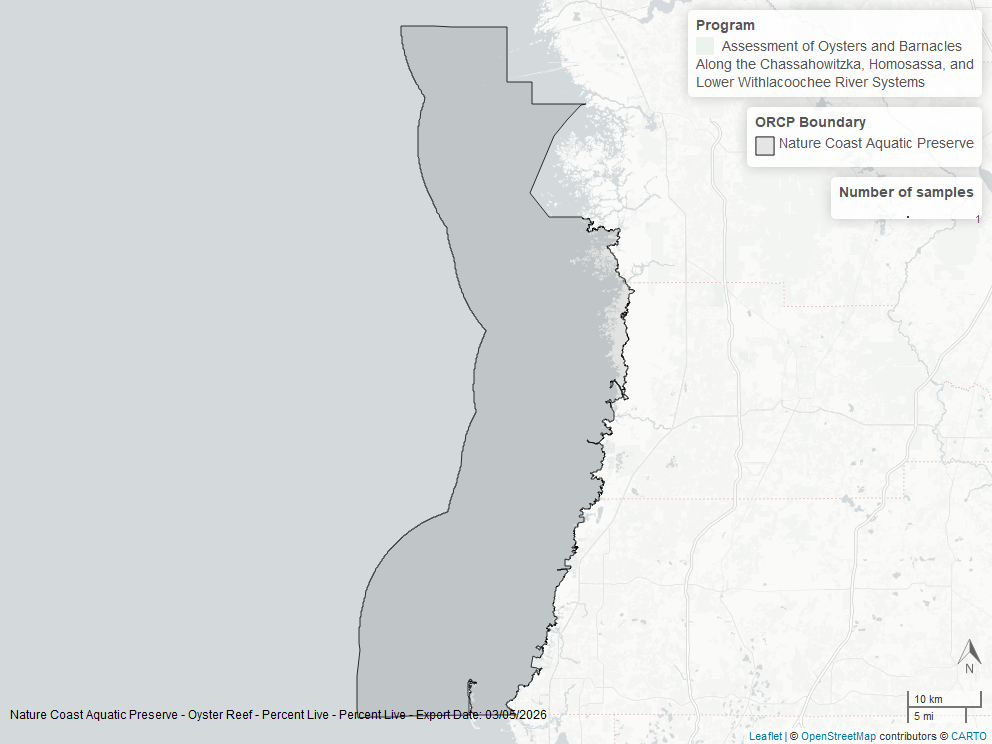

Map showing location of oyster percent live sampling locations within the boundaries of *Nature Coast Aquatic Preserve*. The bubble size on the maps above reflect the amount of data available at each sampling site.

## Shell Height

For natural reefs, there was insufficient data to calculate a trend for live oysters in either the 25-75mm or the ≥75mm size class.

### Natural

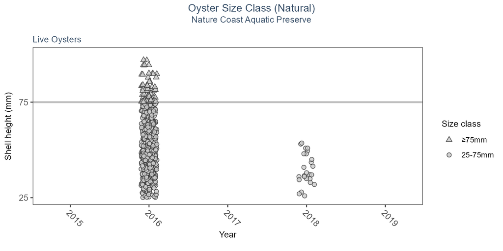

Model results for Oyster Shell Height - Natural

| Habitat Type | Shell Type | SizeClass | Statistical Trend | Period of Record | No. of Samples | Estimate | Standard Error | Credible Interval |
| --- | --- | --- | --- | --- | --- | --- | --- | --- |
| Natural | Live Oysters | >75mm | Insufficient data | 2016 - 2016 | 56 | - | - | - |
| Natural | Live Oysters | 25-75mm | Insufficient data | 2016 - 2018 | 503 | - | - | - |

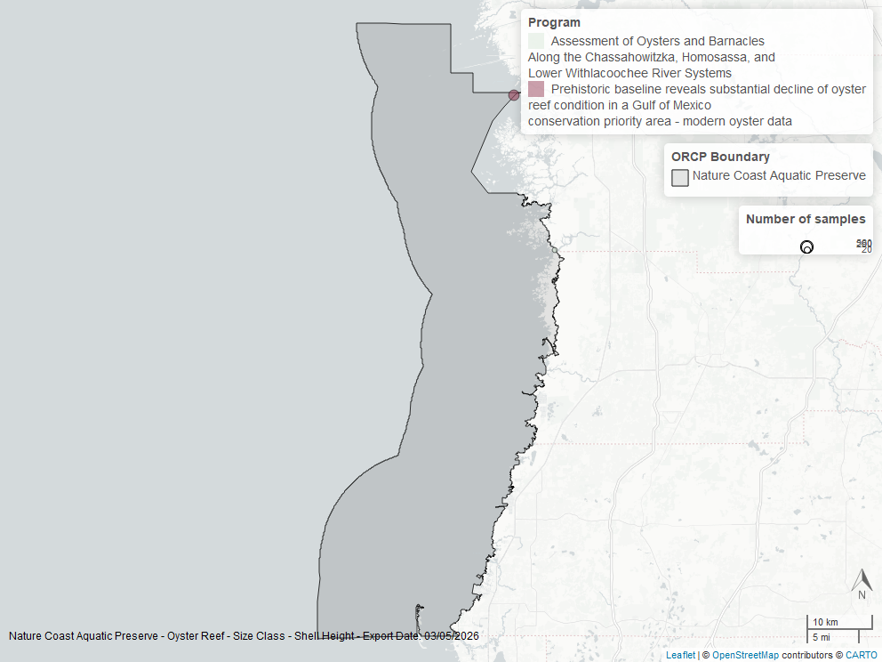

Map showing location of oyster shell height sampling locations within the boundaries of *Nature Coast Aquatic Preserve*. The bubble size on the maps above reflect the amount of data available at each sampling site.

# Species list

| Acetabularia crenulata<sup>1</sup> | Drift algae<sup>1</sup> | Rhizophora mangle<sup>2</sup> |
| --- | --- | --- |
| Acrostichum danaeifolium | Forestiera segregata | Ruppia maritima<sup>1</sup> |
| Anadyomene stellata<sup>1</sup> | Halimeda incrassata<sup>1</sup> | Sabal palmetto |
| Avicennia germinans<sup>2</sup> | Halodule wrightii<sup>1</sup> | Sargassum sp.<sup>1</sup> |
| Avrainvillea levis<sup>1</sup> | Halophila engelmannii<sup>1</sup> | Schinus terebinthifolia |
| Batophora oerstedii<sup>1</sup> | Ilex vomitoria | Smilax bona-nox |
| Caulerpa ashmeadii<sup>1</sup> | Juncus roemerianus<sup>2</sup> | Spartina alterniflora<sup>2</sup> |
| Caulerpa cupressoides<sup>1</sup> | Laguncularia racemosa<sup>2</sup> | Stenotaphrum secundatum |
| Caulerpa mexicana<sup>1</sup> | Lycium carolinianum | Syringodium filiforme<sup>1</sup> |
| Caulerpa paspaloides<sup>1</sup> | No grass in quadrat<sup>1</sup> | Thalassia testudinum<sup>1</sup> |
| Caulerpa prolifera<sup>1</sup> | Padina<sup>1</sup> | Udotea flabellum<sup>1</sup> |
| Caulerpa racemosa<sup>1</sup> | Padina gymnospora<sup>1</sup> | Udotea spp.<sup>1</sup> |
| Caulerpa sertularioides<sup>1</sup> | Penicillus capitatus<sup>1</sup> | Ulva sp.<sup>1</sup> |
| Cladium mariscus | Penicillus dumetosus<sup>1</sup> | Unidentified species |
| Cliona caribbaea | Penicillus spp.<sup>1</sup> | Woody debris |
| Codium isthmocladum<sup>1</sup> | Pneumatophore | Yucca aloifolia |
| Digenea simplex<sup>1</sup> | Quercus virginiana | Acetabularia crenulata<sup>1</sup> |
| Distichlis spicata<sup>2</sup> | Rhipocephalus phoenix<sup>1</sup> | Acrostichum danaeifolium |

1 - Submerged Aquatic Vegetation, 2 - Coastal Wetlands

# References

1.

University of Florida (UF); Florida Department of Environmental Protection (DEP); Office of Resilience and Coastal Protection (RCP); Big Bend Seagrasses Aquatic Preserves / Nature Coast Aquatic Preserve. [Project COAST (Coastal Assessment Team) - Springs Coast Ecosystem Region](https://data.florida-seacar.org/programs/details/5008). (2024).

2.

Southwest Florida Water Management District (SWFWMD). [Southwest Florida Water Management District - Water Quality Monitoring](https://data.florida-seacar.org/programs/details/479). (2024).

3.

Florida Department of Environmental Protection (DEP). [Florida STORET / WIN](https://data.florida-seacar.org/programs/details/5002). (2024).

4.

University of Florida (UF); Institute of Food and Agricultural Sciences. [Florida LAKEWATCH Program](https://data.florida-seacar.org/programs/details/514). (2024).

5.

Florida Department of Agriculture and Consumer Services (FDACS) - Division of Aquaculture. [Shellfish Harvest Area Classification Program](https://data.florida-seacar.org/programs/details/540). (2022).

6.

U.S. Environmental Protection Agency (EPA); Office of Water; National Oceanic and Atmospheric Administration (NOAA); U.S. Geological Survey (USGS); U.S. Fish and Wildlife Service (USFWS); National Estuary Program (NEP); coastal states. [National Aquatic Resource Surveys, National Coastal Condition Assessment](https://data.florida-seacar.org/programs/details/118). (2021).

7.

U.S. Environmental Protection Agency (EPA). [EPA STOrage and RETrieval Data Warehouse (STORET)/WQX](https://data.florida-seacar.org/programs/details/103). (2023).

8.

Florida Fish and Wildlife Conservation Commission (FWC). [Fisheries-Independent Monitoring (FIM) Program](https://data.florida-seacar.org/programs/details/69). (2022).

9.

Florida Fish and Wildlife Conservation Commission (FWC); Florida Fish and Wildlife Research Institute (FWRI). [Harmful Algal Bloom Marine Observation Network](https://data.florida-seacar.org/programs/details/95). (2018).

10.

Gulf States Marine Fisheries Commission. [Southeast Area Monitoring and Assessment Program (SEAMAP) - Gulf of Mexico Fall & Summer Shrimp/Groundfish Survey](https://data.florida-seacar.org/programs/details/60). (2016).

11.

U.S. Environmental Protection Agency (EPA); Office of Research and Development. [Environmental Monitoring Assessment Program](https://data.florida-seacar.org/programs/details/115). (2004).

12.

Florida Department of Environmental Protection (DEP); Office of Resilience and Coastal Protection (RCP); Big Bend Seagrasses Aquatic Preserves; University of Florida - Nature Coast Aquatic Preserve. [Big Bend Seagrasses & Nature Coast Aquatic Preserves - Seagrass Monitoring](https://data.florida-seacar.org/programs/details/560). (2024).

13.

National Oceanic and Atmospheric Administration (NOAA); Atlantic Oceanographic and Meterological Laboratory. [Atlantic Oceanographic and Meteorological Laboratory (AOML) South Florida Program Synoptic Shipboard Surveys](https://data.florida-seacar.org/programs/details/3). (2024).

14.

U.S. Geological Survey (USGS). [National Water Information System](https://data.florida-seacar.org/programs/details/7). (2024).

15.

Florida Department of Environmental Protection (DEP); Office of Resilience and Coastal Protection (RCP); Big Bend Seagrasses Aquatic Preserves. [Big Bend Seagrasses Aquatic Preserves Continuous Water Quality Monitoring](https://data.florida-seacar.org/programs/details/471). (2024).